# **Description**

**Model 1 - Basic Model with SGD Optimizer**

```python
backend.clear_session()
#Fixing the seed for random number generators so that we can ensure we receive the same output everytime
np.random.seed(42)
import random
random.seed(42)
tf.random.set_seed(42)
```

```python
# Initializing the ANN
model = Sequential()
# The amount of nodes (dimensions) in hidden layer should be the average of input and output layers, in this case 64.
# This adds the input layer (by specifying input dimension) AND the first hidden layer (units)
model.add(Dense(activation = 'relu', input_dim = X_train.shape[1], units=64))
#Add 2nd hidden layer
model.add(Dense(32, activation='relu'))
# Adding the output layer
# Notice that we do not need to specify input dim.
# we have an output of 1 node, which is the the desired dimensions of our output (stay with the bank or not)
# We use the sigmoid because we want probability outcomes
model.add(Dense(1, activation = 'sigmoid'))
```

```python
# Create optimizer with default learning rate
# Compile the model
model.compile(optimizer='SGD', loss='binary_crossentropy', metrics=['accuracy'])
```

```python
model.summary()
```

```
Model: "sequential"
_________________________________________________________________
 Layer (type)                Output Shape              Param #
=================================================================
 dense (Dense)               (None, 64)                1472

 dense_1 (Dense)             (None, 32)                2080

 dense_2 (Dense)             (None, 1)                 33

=================================================================
Total params: 3,585
Trainable params: 3,585
Non-trainable params: 0
_________________________________________________________________
```

```python
history=model.fit(X_train, y_train,
          validation_split=0.2,
          epochs=50,
          batch_size=32,verbose=1)
```

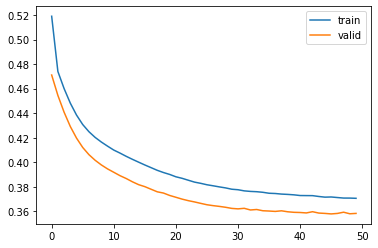

```python
# Capturing learning history per epoch
hist  = pd.DataFrame(history.history)
hist['epoch'] = history.epoch

# Plotting accuracy at different epochs
plt.plot(hist['loss'])
plt.plot(hist['val_loss'])
plt.legend(("train" , "valid") , loc =0)

#Printing results
results = model.evaluate(X_test, y_test)
```

```python
hist
```

|  | loss | accuracy | val_loss | val_accuracy | epoch |
| --- | --- | --- | --- | --- | --- |
| 0 | 0.519067 | 0.792149 | 0.471119 | 0.802377 | 0 |
| 1 | 0.474010 | 0.795590 | 0.454477 | 0.802377 | 1 |
| 2 | 0.460065 | 0.795590 | 0.440788 | 0.802377 | 2 |
| 3 | 0.448187 | 0.795590 | 0.429125 | 0.802377 | 3 |
| 4 | 0.438456 | 0.796059 | 0.419661 | 0.803002 | 4 |
| 5 | 0.430712 | 0.800125 | 0.411996 | 0.802377 | 5 |
| 6 | 0.424855 | 0.804661 | 0.406141 | 0.805503 | 6 |
| 7 | 0.420213 | 0.812011 | 0.401557 | 0.812383 | 7 |
| 8 | 0.416423 | 0.813262 | 0.397748 | 0.814259 | 8 |
| 9 | 0.413075 | 0.817329 | 0.394511 | 0.814259 | 9 |
| 10 | 0.409882 | 0.819049 | 0.391767 | 0.818011 | 10 |
| 11 | 0.407419 | 0.821395 | 0.388996 | 0.822389 | 11 |
| 12 | 0.404781 | 0.827651 | 0.386676 | 0.823640 | 12 |
| 13 | 0.402336 | 0.829997 | 0.383999 | 0.828643 | 13 |
| 14 | 0.400012 | 0.830466 | 0.381662 | 0.829894 | 14 |
| 15 | 0.397719 | 0.832186 | 0.380041 | 0.829894 | 15 |
| 16 | 0.395548 | 0.832343 | 0.377930 | 0.831770 | 16 |
| 17 | 0.393366 | 0.833594 | 0.375835 | 0.835522 | 17 |
| 18 | 0.391556 | 0.836566 | 0.374812 | 0.834897 | 18 |
| 19 | 0.390003 | 0.835784 | 0.372860 | 0.834271 | 19 |
| 20 | 0.388085 | 0.837035 | 0.371372 | 0.841776 | 20 |
| 21 | 0.386838 | 0.837035 | 0.369862 | 0.836773 | 21 |
| 22 | 0.385275 | 0.837348 | 0.368611 | 0.841776 | 22 |
| 23 | 0.383739 | 0.837504 | 0.367572 | 0.841151 | 23 |
| 24 | 0.382743 | 0.838130 | 0.366398 | 0.844278 | 24 |
| 25 | 0.381584 | 0.840788 | 0.365274 | 0.841776 | 25 |
| 26 | 0.380737 | 0.840475 | 0.364541 | 0.844903 | 26 |
| 27 | 0.379837 | 0.836722 | 0.363934 | 0.845528 | 27 |
| 28 | 0.379014 | 0.840319 | 0.363208 | 0.845528 | 28 |
| 29 | 0.377939 | 0.839537 | 0.362297 | 0.848030 | 29 |
| 30 | 0.377530 | 0.840319 | 0.361917 | 0.848655 | 30 |
| 31 | 0.376599 | 0.842665 | 0.362365 | 0.843027 | 31 |
| 32 | 0.376155 | 0.839850 | 0.361011 | 0.851157 | 32 |
| 33 | 0.375915 | 0.841570 | 0.361396 | 0.846154 | 33 |
| 34 | 0.375431 | 0.843134 | 0.360378 | 0.852408 | 34 |
| 35 | 0.374652 | 0.842509 | 0.360147 | 0.853659 | 35 |
| 36 | 0.374447 | 0.841727 | 0.359836 | 0.852408 | 36 |
| 37 | 0.373971 | 0.842196 | 0.360331 | 0.848030 | 37 |
| 38 | 0.373716 | 0.841414 | 0.359538 | 0.853033 | 38 |
| 39 | 0.373362 | 0.841727 | 0.359102 | 0.850532 | 39 |
| 40 | 0.372795 | 0.841570 | 0.358954 | 0.851157 | 40 |
| 41 | 0.372744 | 0.842196 | 0.358595 | 0.853033 | 41 |
| 42 | 0.372701 | 0.841257 | 0.359593 | 0.849281 | 42 |
| 43 | 0.372024 | 0.843291 | 0.358492 | 0.849906 | 43 |
| 44 | 0.371473 | 0.843291 | 0.358209 | 0.851157 | 44 |
| 45 | 0.371613 | 0.841570 | 0.357795 | 0.852408 | 45 |
| 46 | 0.371159 | 0.843291 | 0.358191 | 0.849906 | 46 |
| 47 | 0.370728 | 0.844073 | 0.359187 | 0.848655 | 47 |
| 48 | 0.370709 | 0.841414 | 0.357912 | 0.850532 | 48 |
| 49 | 0.370526 | 0.843134 | 0.358211 | 0.849281 | 49 |

```
Best Threshold=0.210501, G-Mean=0.762
```

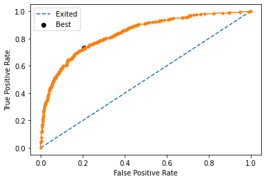

```python
from sklearn.metrics import roc_curve

from matplotlib import pyplot


# predict probabilities
yhat1 = model.predict(X_test)
# keep probabilities for the positive outcome only
yhat1 = yhat1[:, 0]
# calculate roc curves
fpr, tpr, thresholds1 = roc_curve(y_test, yhat1)
# calculate the g-mean for each threshold
gmeans1 = np.sqrt(tpr * (1-fpr))
# locate the index of the largest g-mean
ix = np.argmax(gmeans1)
print('Best Threshold=%f, G-Mean=%.3f' % (thresholds1[ix], gmeans1[ix]))
# plot the roc curve for the model
pyplot.plot([0,1], [0,1], linestyle='--', label='Exited')
pyplot.plot(fpr, tpr, marker='.')
pyplot.scatter(fpr[ix], tpr[ix], marker='o', color='black', label='Best')
# axis labels
pyplot.xlabel('False Positive Rate')
pyplot.ylabel('True Positive Rate')
pyplot.legend()
# show the plot
pyplot.show()
```

```python
#Predicting the results using best as a threshold
y_pred_1=model.predict(X_test)
y_pred_1 = (y_pred_1 > thresholds1[ix])
y_pred_1
```

```
array([[ True],
       [ True],
       [False],
       ...,
       [ True],
       [ True],
       [False]])
```

```python
thresholds11=thresholds1[ix]
```

```python
def make_confusion_matrix(cf,
                          group_names=None,
                          categories='auto',
                          count=True,
                          percent=True,
                          cbar=True,
                          xyticks=True,
                          xyplotlabels=True,
                          sum_stats=True,
                          figsize=None,
                          cmap='Blues',
                          title=None):
    '''
    This function will make a pretty plot of an sklearn Confusion Matrix cm using a Seaborn heatmap visualization.
    Arguments
    '''


    # CODE TO GENERATE TEXT INSIDE EACH SQUARE
    blanks = ['' for i in range(cf.size)]

    if group_names and len(group_names)==cf.size:
        group_labels = ["{}\n".format(value) for value in group_names]
    else:
        group_labels = blanks

    if count:
        group_counts = ["{0:0.0f}\n".format(value) for value in cf.flatten()]
    else:
        group_counts = blanks

    if percent:
        group_percentages = ["{0:.2%}".format(value) for value in cf.flatten()/np.sum(cf)]
    else:
        group_percentages = blanks

    box_labels = [f"{v1}{v2}{v3}".strip() for v1, v2, v3 in zip(group_labels,group_counts,group_percentages)]
    box_labels = np.asarray(box_labels).reshape(cf.shape[0],cf.shape[1])


    # CODE TO GENERATE SUMMARY STATISTICS & TEXT FOR SUMMARY STATS
    if sum_stats:
        #Accuracy is sum of diagonal divided by total observations
        accuracy  = np.trace(cf) / float(np.sum(cf))



    # SET FIGURE PARAMETERS ACCORDING TO OTHER ARGUMENTS
    if figsize==None:
        #Get default figure size if not set
        figsize = plt.rcParams.get('figure.figsize')

    if xyticks==False:
        #Do not show categories if xyticks is False
        categories=False


    # MAKE THE HEATMAP VISUALIZATION
    plt.figure(figsize=figsize)
    sns.heatmap(cf,annot=box_labels,fmt="",cmap=cmap,cbar=cbar,xticklabels=categories,yticklabels=categories)


    if title:
        plt.title(title)
```

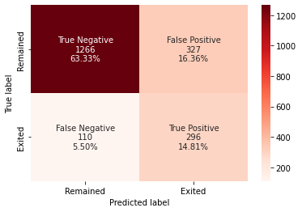

```python
#Calculating the confusion matrix
from sklearn.metrics import confusion_matrix
cm1=confusion_matrix(y_test, y_pred_1)
labels = ['True Negative','False Positive','False Negative','True Positive']
categories = [ 'Remained','Exited']
make_confusion_matrix(cm1,
                      group_names=labels,
                      categories=categories,
                      cmap='Reds')
plt.ylabel("True label")
plt.xlabel("Predicted label")
```

```python
y_test.value_counts()
```

```
Exited
0         1593
1          406
dtype: int64
```

```python
#Accuracy as per the classification report
from sklearn import metrics
cr=metrics.classification_report(y_test,y_pred_1)
print(cr)
```

```
              precision    recall  f1-score   support

           0       0.92      0.79      0.85      1593
           1       0.48      0.73      0.58       406

    accuracy                           0.78      1999
   macro avg       0.70      0.76      0.71      1999
weighted avg       0.83      0.78      0.80      1999
```

**Model 2 - Basic Model with Adam Optimizer**

```python
backend.clear_session()
#Fixing the seed for random number generators so that we can ensure we receive the same output everytime
np.random.seed(42)
import random
random.seed(42)
tf.random.set_seed(42)
```

```python
# Initializing the ANN
model2 = Sequential()
#Add input and 1st hidden layer
model2.add(Dense(units=128, activation='relu',kernel_initializer='he_uniform', input_dim = X_train.shape[1]))
#Add 2nd hidden layer
model2.add(Dense(64, activation='relu',kernel_initializer='he_uniform',))

# Adding the output layer
# Notice that we do not need to specify input dim.
# we have an output of 1 node, which is the the desired dimensions of our output (stay with the bank or not)
# We use the sigmoid because we want probability outcomes
model2.add(Dense(1, activation = 'sigmoid'))
```

```python
# Create optimizer with default learning rate
# Compile the model
model2.compile(optimizer='Adam', loss='binary_crossentropy', metrics=['accuracy'])
```

```python
model2.summary()
```

```
Model: "sequential"
_________________________________________________________________
 Layer (type)                Output Shape              Param #
=================================================================
 dense (Dense)               (None, 128)               2944

 dense_1 (Dense)             (None, 64)                8256

 dense_2 (Dense)             (None, 1)                 65

=================================================================
Total params: 11,265
Trainable params: 11,265
Non-trainable params: 0
_________________________________________________________________
```

```python
history2=model2.fit(X_train, y_train,
          validation_split=0.2,
          epochs=50,
          batch_size=32,verbose=1)
```

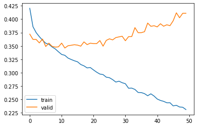

```python
# Capturing learning history per epoch
hist2  = pd.DataFrame(history2.history)
hist2['epoch'] = history2.epoch

# Plotting accuracy at different epochs
plt.plot(hist2['loss'])
plt.plot(hist2['val_loss'])
plt.legend(("train" , "valid") , loc =0)

#Printing results
results_2 = model2.evaluate(X_test, y_test)
```

```
Best Threshold=0.115267, G-Mean=0.755
```

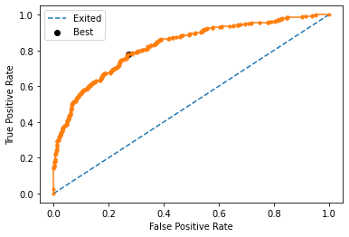

```python
from sklearn.metrics import roc_curve

from matplotlib import pyplot


# predict probabilities
yhat2 = model2.predict(X_test)
# keep probabilities for the positive outcome only
yhat2 = yhat2[:, 0]
# calculate roc curves
fpr, tpr, thresholds1 = roc_curve(y_test, yhat2)
# calculate the g-mean for each threshold
gmeans2 = np.sqrt(tpr * (1-fpr))
# locate the index of the largest g-mean
ix2 = np.argmax(gmeans2)
print('Best Threshold=%f, G-Mean=%.3f' % (thresholds1[ix2], gmeans2[ix2]))
# plot the roc curve for the model
pyplot.plot([0,1], [0,1], linestyle='--', label='Exited')
pyplot.plot(fpr, tpr, marker='.')
pyplot.scatter(fpr[ix2], tpr[ix2], marker='o', color='black', label='Best')
# axis labels
pyplot.xlabel('False Positive Rate')
pyplot.ylabel('True Positive Rate')
pyplot.legend()
# show the plot
pyplot.show()
```

```python
#Predicting the results using best as a threshold
y_pred_2=model2.predict(X_test)
y_pred_2 = (y_pred_2 > thresholds1[ix2])
y_pred_2
```

```
array([[False],
       [False],
       [False],
       ...,
       [ True],
       [ True],
       [False]])
```

```python
thresholds2=thresholds1[ix2]
```

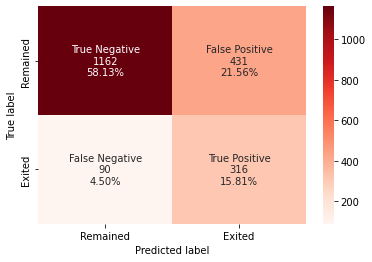

```python
#Calculating the confusion matrix
from sklearn.metrics import confusion_matrix
cm2=confusion_matrix(y_test, y_pred_2)
labels = ['True Negative','False Positive','False Negative','True Positive']
categories = [ 'Remained','Exited']
make_confusion_matrix(cm2,
                      group_names=labels,
                      categories=categories,
                      cmap='Reds')
plt.ylabel("True label")
plt.xlabel("Predicted label")
```

```python
#Accuracy as per the classification report
from sklearn import metrics
cr2=metrics.classification_report(y_test,y_pred_2)
print(cr2)
```

```
              precision    recall  f1-score   support

           0       0.93      0.73      0.82      1593
           1       0.42      0.78      0.55       406

    accuracy                           0.74      1999
   macro avg       0.68      0.75      0.68      1999
weighted avg       0.83      0.74      0.76      1999
```

**Model 3 - with BatchNormalization**

```python
backend.clear_session()
#Fixing the seed for random number generators so that we can ensure we receive the same output everytime
np.random.seed(42)
import random
random.seed(42)
tf.random.set_seed(42)
```

```python
# Initializing the ANN
model3 = Sequential()
#Add input and 1st hidden layer
model3.add(Dense(units=128, activation='relu',kernel_initializer='he_uniform', input_dim = X_train.shape[1]))
model3.add(BatchNormalization())
#Add 2nd hidden layer
model3.add(Dense(64, activation='relu',kernel_initializer='he_uniform',))

# Adding the output layer
# Notice that we do not need to specify input dim.
# we have an output of 1 node, which is the the desired dimensions of our output (stay with the bank or not)
# We use the sigmoid because we want probability outcomes
model3.add(Dense(1, activation = 'sigmoid'))
```

```python
model3.summary()
```

```
Model: "sequential"
_________________________________________________________________
 Layer (type)                Output Shape              Param #
=================================================================
 dense (Dense)               (None, 128)               2944

 batch_normalization (BatchN  (None, 128)              512
 ormalization)

 dense_1 (Dense)             (None, 64)                8256

 dense_2 (Dense)             (None, 1)                 65

=================================================================
Total params: 11,777
Trainable params: 11,521
Non-trainable params: 256
_________________________________________________________________
```

```python
# Create optimizer with default learning rate
# Compile the model
model3.compile(optimizer='Adam', loss='binary_crossentropy', metrics=['accuracy'])
```

```python
history3=model3.fit(X_train, y_train,
          validation_split=0.2,
          epochs=50,
          batch_size=32,verbose=1)
```

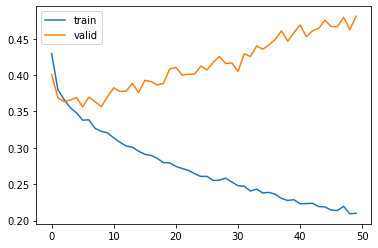

```python
# Capturing learning history per epoch
hist3  = pd.DataFrame(history3.history)
hist3['epoch'] = history3.epoch

# Plotting accuracy at different epochs
plt.plot(hist3['loss'])
plt.plot(hist3['val_loss'])
plt.legend(("train" , "valid") , loc =0)

#Printing results
results_3 = model3.evaluate(X_test, y_test)
```

```
Best Threshold=0.107303, G-Mean=0.738
```

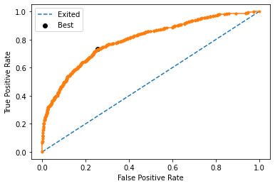

```python
from sklearn.metrics import roc_curve

from matplotlib import pyplot


# predict probabilities
yhat3 = model3.predict(X_test)
# keep probabilities for the positive outcome only
yhat3 = yhat3[:, 0]
# calculate roc curves
fpr, tpr, thresholds1 = roc_curve(y_test, yhat3)
# calculate the g-mean for each threshold
gmeans3 = np.sqrt(tpr * (1-fpr))
# locate the index of the largest g-mean
ix3 = np.argmax(gmeans3)
print('Best Threshold=%f, G-Mean=%.3f' % (thresholds1[ix3], gmeans3[ix3]))
# plot the roc curve for the model
pyplot.plot([0,1], [0,1], linestyle='--', label='Exited')
pyplot.plot(fpr, tpr, marker='.')
pyplot.scatter(fpr[ix3], tpr[ix3], marker='o', color='black', label='Best')
# axis labels
pyplot.xlabel('False Positive Rate')
pyplot.ylabel('True Positive Rate')
pyplot.legend()
# show the plot
pyplot.show()
```

```python
#Predicting the results using best as a threshold
y_pred_3=model.predict(X_test)
y_pred_3 = (y_pred_3 > thresholds1[ix3])
y_pred_3
```

```
array([[ True],
       [ True],
       [False],
       ...,
       [ True],
       [ True],
       [False]])
```

```python
thresholds3=thresholds1[ix3]
```

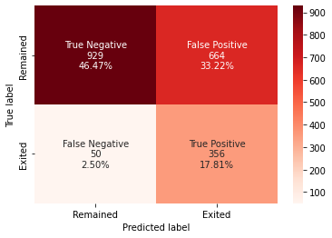

```python
#Calculating the confusion matrix
from sklearn.metrics import confusion_matrix
cm3=confusion_matrix(y_test, y_pred_3)
labels = ['True Negative','False Positive','False Negative','True Positive']
categories = [ 'Remained','Exited']
make_confusion_matrix(cm3,
                      group_names=labels,
                      categories=categories,
                      cmap='Reds')
plt.ylabel("True label")
plt.xlabel("Predicted label")
```

```python
#Accuracy as per the classification report
from sklearn import metrics
cr3=metrics.classification_report(y_test,y_pred_3)
print(cr3)
```

```
              precision    recall  f1-score   support

           0       0.95      0.58      0.72      1593
           1       0.35      0.88      0.50       406

    accuracy                           0.64      1999
   macro avg       0.65      0.73      0.61      1999
weighted avg       0.83      0.64      0.68      1999
```

**Model 4 - with Dropout**

```python
backend.clear_session()
#Fixing the seed for random number generators so that we can ensure we receive the same output everytime
np.random.seed(42)
import random
random.seed(42)
tf.random.set_seed(42)
```

```python
# Initializing the ANN
model4 = Sequential()
#Add input and 1st hidden layer
model4.add(Dense(units=128, activation='relu',kernel_initializer='he_uniform', input_dim = X_train.shape[1]))
model4.add(Dropout(0.2))
#Add 2nd hidden layer
model4.add(Dense(64, activation='relu',kernel_initializer='he_uniform',))

# Adding the output layer
# Notice that we do not need to specify input dim.
# we have an output of 1 node, which is the the desired dimensions of our output (stay with the bank or not)
# We use the sigmoid because we want probability outcomes
model4.add(Dense(1, activation = 'sigmoid'))
```

```python
model4.summary()
```

```
Model: "sequential"
_________________________________________________________________
 Layer (type)                Output Shape              Param #
=================================================================
 dense (Dense)               (None, 128)               2944

 dropout (Dropout)           (None, 128)               0

 dense_1 (Dense)             (None, 64)                8256

 dense_2 (Dense)             (None, 1)                 65

=================================================================
Total params: 11,265
Trainable params: 11,265
Non-trainable params: 0
_________________________________________________________________
```

```python
from tensorflow.keras import losses
from tensorflow.keras import optimizers
from tensorflow.keras import Sequential
from tensorflow.keras.layers import Dense
```

```python
# Create optimizer with default learning rate
# Compile the model
Adam = optimizers.Adam(lr=1e-3)
model4.compile(loss=losses.binary_crossentropy, optimizer=Adam, metrics=['accuracy'])
```

```python
history4=model4.fit(X_train, y_train,
          validation_split=0.2,
          epochs=50,
          batch_size=32,verbose=1)
```

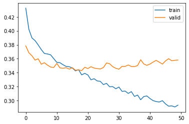

```python
# Capturing learning history per epoch
hist4  = pd.DataFrame(history4.history)
hist4['epoch'] = history4.epoch

# Plotting accuracy at different epochs
plt.plot(hist4['loss'])
plt.plot(hist4['val_loss'])
plt.legend(("train" , "valid") , loc =0)

#Printing results
results_4 = model4.evaluate(X_test, y_test)
```

```
Best Threshold=0.148645, G-Mean=0.763
```

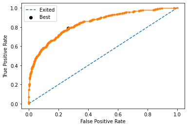

```python
from sklearn.metrics import roc_curve

from matplotlib import pyplot


# predict probabilities
yhat4 = model4.predict(X_test)
# keep probabilities for the positive outcome only
yhat4 = yhat4[:, 0]
# calculate roc curves
fpr, tpr, thresholds1 = roc_curve(y_test, yhat4)
# calculate the g-mean for each threshold
gmeans4 = np.sqrt(tpr * (1-fpr))
# locate the index of the largest g-mean
ix4 = np.argmax(gmeans4)
print('Best Threshold=%f, G-Mean=%.3f' % (thresholds1[ix4], gmeans4[ix4]))
# plot the roc curve for the model
pyplot.plot([0,1], [0,1], linestyle='--', label='Exited')
pyplot.plot(fpr, tpr, marker='.')
pyplot.scatter(fpr[ix4], tpr[ix4], marker='o', color='black', label='Best')
# axis labels
pyplot.xlabel('False Positive Rate')
pyplot.ylabel('True Positive Rate')
pyplot.legend()
# show the plot
pyplot.show()
```

```python
#Predicting the results using best as a threshold
y_pred_4=model.predict(X_test)
y_pred_4 = (y_pred_4 > thresholds1[ix4])
y_pred_4
```

```
array([[ True],
       [ True],
       [False],
       ...,
       [ True],
       [ True],
       [False]])
```

```python
thresholds4=thresholds1[ix4]
```

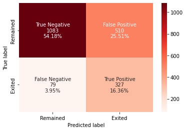

```python
#Calculating the confusion matrix
from sklearn.metrics import confusion_matrix
cm4=confusion_matrix(y_test, y_pred_4)
labels = ['True Negative','False Positive','False Negative','True Positive']
categories = [ 'Remained','Exited']
make_confusion_matrix(cm4,
                      group_names=labels,
                      categories=categories,
                      cmap='Reds')
plt.ylabel("True label")
plt.xlabel("Predicted label")
```

```python
#Accuracy as per the classification report
from sklearn import metrics
cr4=metrics.classification_report(y_test,y_pred_4)
print(cr4)
```

```
              precision    recall  f1-score   support

           0       0.93      0.68      0.79      1593
           1       0.39      0.81      0.53       406

    accuracy                           0.71      1999
   macro avg       0.66      0.74      0.66      1999
weighted avg       0.82      0.71      0.73      1999
```

**Early Stopping**

**Model 5 - with Early Stopping**

```python
#Apply early stopping to model 4 (the best model so far)
backend.clear_session()
#Fixing the seed for random number generators so that we can ensure we receive the same output everytime
np.random.seed(42)
import random
random.seed(42)
tf.random.set_seed(42)
```

```python
# Initializing the ANN
model5 = Sequential()
#Add input and 1st hidden layer
model5.add(Dense(units=128, activation='relu',kernel_initializer='he_uniform', input_dim = X_train.shape[1]))
model5.add(Dropout(0.2))
#Add 2nd hidden layer
model5.add(Dense(64, activation='relu',kernel_initializer='he_uniform',))

# Adding the output layer
# Notice that we do not need to specify input dim.
# we have an output of 1 node, which is the the desired dimensions of our output (stay with the bank or not)
# We use the sigmoid because we want probability outcomes
model5.add(Dense(1, activation = 'sigmoid'))
```

```python
model5.summary()
```

```
Model: "sequential"
_________________________________________________________________
 Layer (type)                Output Shape              Param #
=================================================================
 dense (Dense)               (None, 128)               2944

 dropout (Dropout)           (None, 128)               0

 dense_1 (Dense)             (None, 64)                8256

 dense_2 (Dense)             (None, 1)                 65

=================================================================
Total params: 11,265
Trainable params: 11,265
Non-trainable params: 0
_________________________________________________________________
```

```python
# Create optimizer with default learning rate
# Compile the model
Adam = optimizers.Adam(lr=1e-3)
model5.compile(loss=losses.binary_crossentropy, optimizer=Adam, metrics=['accuracy'])
```

```python
from tensorflow.keras.callbacks import EarlyStopping  #regularization method to prevent the overfitting
```

```python
# Defining Early stopping
#es_cb = callbacks.EarlyStopping(monitor='val_loss', min_delta=0.001, patience=5)
es = EarlyStopping(monitor='val_loss', mode='min', verbose=1, patience=5)
mc = ModelCheckpoint('best_model.h5', monitor='val_accuracy', mode='max', verbose=1, save_best_only=True)
```

```python
history5=model5.fit(X_train, y_train,
          validation_split=0.2,
          epochs=50,
          batch_size=32,verbose=1, callbacks=[es, mc])
```

```
Epoch 1: val_accuracy improved from -inf to 0.83615, saving model to best_model.h5
Epoch 2: val_accuracy improved from 0.83615 to 0.84553, saving model to best_model.h5
Epoch 3: val_accuracy improved from 0.84553 to 0.84928, saving model to best_model.h5
Epoch 4: val_accuracy did not improve from 0.84928
Epoch 5: val_accuracy did not improve from 0.84928
Epoch 6: val_accuracy improved from 0.84928 to 0.85616, saving model to best_model.h5
Epoch 7: val_accuracy improved from 0.85616 to 0.85679, saving model to best_model.h5
Epoch 8: val_accuracy improved from 0.85679 to 0.86054, saving model to best_model.h5
Epoch 9: val_accuracy did not improve from 0.86054
Epoch 10: val_accuracy did not improve from 0.86054
Epoch 11: val_accuracy did not improve from 0.86054
Epoch 12: val_accuracy improved from 0.86054 to 0.86116, saving model to best_model.h5
Epoch 13: val_accuracy improved from 0.86116 to 0.86366, saving model to best_model.h5
Epoch 14: val_accuracy did not improve from 0.86366
Epoch 15: val_accuracy did not improve from 0.86366
Epoch 16: val_accuracy did not improve from 0.86366
Epoch 17: val_accuracy did not improve from 0.86366
Epoch 18: val_accuracy did not improve from 0.86366
Epoch 19: val_accuracy did not improve from 0.86366
Epoch 20: val_accuracy did not improve from 0.86366
Epoch 21: val_accuracy did not improve from 0.86366
Epoch 22: val_accuracy did not improve from 0.86366
Epoch 23: val_accuracy did not improve from 0.86366
Epoch 24: val_accuracy did not improve from 0.86366
Epoch 24: early stopping
```

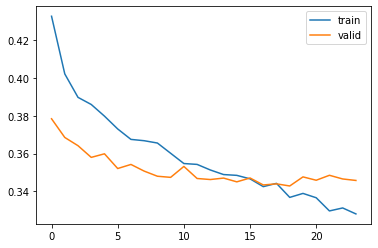

```python
# Capturing learning history per epoch
hist5  = pd.DataFrame(history5.history)
hist5['epoch'] = history5.epoch

# Plotting accuracy at different epochs
plt.plot(hist5['loss'])
plt.plot(hist5['val_loss'])
plt.legend(("train" , "valid") , loc =0)

#Printing results
results_5 = model5.evaluate(X_test, y_test)
```

```
Best Threshold=0.182000, G-Mean=0.768
```

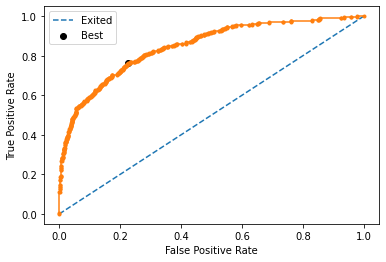

```python
from sklearn.metrics import roc_curve

from matplotlib import pyplot


# predict probabilities
yhat5 = model5.predict(X_test)
# keep probabilities for the positive outcome only
yhat5 = yhat5[:, 0]
# calculate roc curves
fpr, tpr, thresholds1 = roc_curve(y_test, yhat5)
# calculate the g-mean for each threshold
gmeans5 = np.sqrt(tpr * (1-fpr))
# locate the index of the largest g-mean
ix5 = np.argmax(gmeans5)
print('Best Threshold=%f, G-Mean=%.3f' % (thresholds1[ix5], gmeans5[ix5]))
# plot the roc curve for the model
pyplot.plot([0,1], [0,1], linestyle='--', label='Exited')
pyplot.plot(fpr, tpr, marker='.')
pyplot.scatter(fpr[ix5], tpr[ix5], marker='o', color='black', label='Best')
# axis labels
pyplot.xlabel('False Positive Rate')
pyplot.ylabel('True Positive Rate')
pyplot.legend()
# show the plot
pyplot.show()
```

```python
#Predicting the results using best as a threshold
y_pred_5=model.predict(X_test)
y_pred_5 = (y_pred_5 > thresholds1[ix5])
y_pred_5
```

```
array([[ True],
       [ True],
       [False],
       ...,
       [ True],
       [ True],
       [False]])
```

```python
thresholds5=thresholds1[ix5]
```

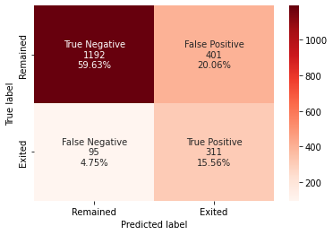

```python
#Calculating the confusion matrix
from sklearn.metrics import confusion_matrix
cm5=confusion_matrix(y_test, y_pred_5)
labels = ['True Negative','False Positive','False Negative','True Positive']
categories = [ 'Remained','Exited']
make_confusion_matrix(cm5,
                      group_names=labels,
                      categories=categories,
                      cmap='Reds')
plt.ylabel("True label")
plt.xlabel("Predicted label")
```

```python
y_test.value_counts()
```

```
Exited
0         1593
1          406
dtype: int64
```

```python
#Accuracy as per the classification report
from sklearn import metrics
cr5=metrics.classification_report(y_test,y_pred_5)
print(cr5)
```

```
              precision    recall  f1-score   support

           0       0.93      0.75      0.83      1593
           1       0.44      0.77      0.56       406

    accuracy                           0.75      1999
   macro avg       0.68      0.76      0.69      1999
weighted avg       0.83      0.75      0.77      1999
```

```python
thresholds5
```

```
0.18199965
```

**Model 6 - with Dropout and Hyperparameter Tuning**

```python
backend.clear_session()
np.random.seed(42)
import random
random.seed(42)
tf.random.set_seed(42)
```

```python
def create_model_v6(lr,batch_size):
    np.random.seed(42)
    model6 = Sequential()
    #Add input and 1st hidden layer
    model6.add(Dense(units=128, activation='relu',kernel_initializer='he_uniform', input_dim = X_train.shape[1]))
    model6.add(Dropout(0.2))
    #Add 2nd hidden layer
    model6.add(Dense(64, activation='relu',kernel_initializer='he_uniform',))

    # Adding the output layer
    # Notice that we do not need to specify input dim.
    # we have an output of 1 node, which is the the desired dimensions of our output (stay with the bank or not)
    # We use the sigmoid because we want probability outcomes
    model6.add(Dense(1, activation = 'sigmoid'))

    #compile model6
    optimizer = tf.keras.optimizers.Adam(learning_rate=lr)
    model6.compile(optimizer = optimizer,loss = 'binary_crossentropy', metrics = ['accuracy'])
    return model6
```

```python
keras_estimator = KerasClassifier(build_fn=create_model_v6, verbose=1)
# define the grid search parameters
param_random = {
    'batch_size':[32, 64, 128],
    "lr":[0.01,0.1,0.001],}

kfold_splits = 3
random= RandomizedSearchCV(estimator=keras_estimator,
                    verbose=1,
                    cv=kfold_splits,
                    param_distributions=param_random,n_jobs=-1)
```

```python
random_result = random.fit(X_train, y_train,validation_split=0.2,verbose=1)

# Summarize results
print("Best: %f using %s" % (random_result.best_score_, random_result.best_params_))
means = random_result.cv_results_['mean_test_score']
stds = random_result.cv_results_['std_test_score']
params = random_result.cv_results_['params']
```

```
Fitting 3 folds for each of 9 candidates, totalling 27 fits
Best: 0.834482 using {'lr': 0.01, 'batch_size': 32}
```

```python
estimator_v6=create_model_v6(batch_size=random_result.best_params_['batch_size'],lr=random_result.best_params_['lr'])

estimator_v6.summary()
```

```
Model: "sequential_1"
_________________________________________________________________
 Layer (type)                Output Shape              Param #
=================================================================
 dense_3 (Dense)             (None, 128)               2944

 dropout_1 (Dropout)         (None, 128)               0

 dense_4 (Dense)             (None, 64)                8256

 dense_5 (Dense)             (None, 1)                 65

=================================================================
Total params: 11,265
Trainable params: 11,265
Non-trainable params: 0
_________________________________________________________________
```

```python
optimizer = tf.keras.optimizers.Adam(random_result.best_params_['lr'])
estimator_v6.compile(loss='binary_crossentropy',optimizer=optimizer,metrics=['accuracy'])
es_cb = callbacks.EarlyStopping(monitor='val_loss', min_delta=0.001, patience=5)
#history_6=estimator_v6.fit(X_train, y_train, epochs=50, batch_size = 64, verbose=1,validation_split=0.2, callbacks=es_cb)
history_6=estimator_v6.fit(X_train, y_train, epochs=50, batch_size = 32, verbose=1,validation_split=0.2)
```

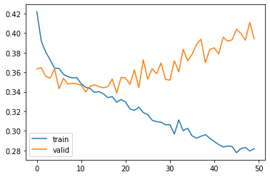

```python
# Capturing learning history per epoch
hist6  = pd.DataFrame(history_6.history)
hist6['epoch'] = history_6.epoch

# Plotting accuracy at different epochs
plt.plot(hist6['loss'])
plt.plot(hist6['val_loss'])
plt.legend(("train" , "valid") , loc =0)

#Printing results
results_6 = estimator_v6.evaluate(X_test, y_test)
```

```python
model6=estimator_v6
```

```
Best Threshold=0.206247, G-Mean=0.768
```

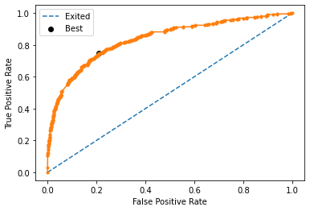

```python
from sklearn.metrics import roc_curve

from matplotlib import pyplot


# predict probabilities
yhat6 = model6.predict(X_test)
# keep probabilities for the positive outcome only
yhat6 = yhat6[:, 0]
# calculate roc curves
fpr, tpr, thresholds1 = roc_curve(y_test, yhat6)
# calculate the g-mean for each threshold
gmeans6 = np.sqrt(tpr * (1-fpr))
# locate the index of the largest g-mean
ix6 = np.argmax(gmeans6)
print('Best Threshold=%f, G-Mean=%.3f' % (thresholds1[ix6], gmeans6[ix6]))
# plot the roc curve for the model
pyplot.plot([0,1], [0,1], linestyle='--', label='Exited')
pyplot.plot(fpr, tpr, marker='.')
pyplot.scatter(fpr[ix6], tpr[ix6], marker='o', color='black', label='Best')
# axis labels
pyplot.xlabel('False Positive Rate')
pyplot.ylabel('True Positive Rate')
pyplot.legend()
# show the plot
pyplot.show()
```

```python
#Predicting the results using best as a threshold
y_pred_6=model.predict(X_test)
y_pred_6 = (y_pred_6 > thresholds1[ix6])
y_pred_6
```

```
array([[ True],
       [ True],
       [False],
       ...,
       [ True],
       [ True],
       [False]])
```

```python
thresholds6=thresholds1[ix6]
```

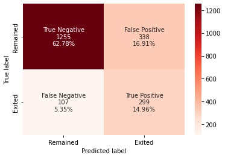

```python
#Calculating the confusion matrix
from sklearn.metrics import confusion_matrix
cm6=confusion_matrix(y_test, y_pred_6)
labels = ['True Negative','False Positive','False Negative','True Positive']
categories = [ 'Remained','Exited']
make_confusion_matrix(cm6,
                      group_names=labels,
                      categories=categories,
                      cmap='Reds')
plt.ylabel("True label")
plt.xlabel("Predicted label")
```

```python
confusion_matrix(y_test, y_pred_6)
```

```
array([[1255,  338],
       [ 107,  299]])
```

```python
#Accuracy as per the classification report
from sklearn import metrics
cr6=metrics.classification_report(y_test,y_pred_6)
print(cr6)
```

```
              precision    recall  f1-score   support

           0       0.92      0.79      0.85      1593
           1       0.47      0.74      0.57       406

    accuracy                           0.78      1999
   macro avg       0.70      0.76      0.71      1999
weighted avg       0.83      0.78      0.79      1999
```

```python
def confusion_matrix_piped(real_target, pred_target):
    """
    To plot the confusion_matrix with percentages

    model: classifier
    predictors: independent variables
    target: dependent variable
    """
    cm = confusion_matrix(real_target, pred_target)
    labels = np.asarray(
        [
            ["{0:0.0f}".format(item) + "\n{0:.2%}".format(item / cm.flatten().sum())]
            for item in cm.flatten()
        ]
    ).reshape(2, 2)

    plt.figure(figsize=(6, 4))
    sns.heatmap(cm, annot=labels, fmt="")
    plt.ylabel("True label")
    plt.xlabel("Predicted label")
```

**Models Performance Evaluation**

```python
backend.clear_session()
np.random.seed(42)
import random
random.seed(42)
tf.random.set_seed(42)
```

```
Threshold =  0.21050149
```

|  | Accuracy | Recall_1 | Recall_0 | Precision_1 | Precision_0 | F1_1 | F1_0 | Threshold |
| --- | --- | --- | --- | --- | --- | --- | --- | --- |
| 0 | 0.781391 | 0.729064 | 0.794727 | 0.47512 | 0.920058 | 0.575316 | 0.852812 | 0.210501 |

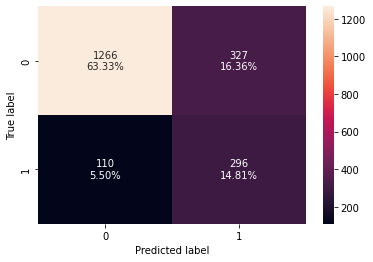

```python
 # predicting using the independent variables
threshold1=thresholds11

confusion_matrix_piped(y_test, y_pred_1)


acc1 = accuracy_score(y_test, y_pred_1)  # to compute Accuracy
recall1 = recall_score(y_test, y_pred_1,pos_label=1)  # to compute Recall
precision1 = precision_score(y_test, y_pred_1,pos_label=1)  # to compute Precision
f11 = f1_score(y_test, y_pred_1,pos_label=1)  # to compute F1-score

recall1_0 = recall_score(y_test, y_pred_1,pos_label=0)  # to compute Recall
precision1_0 = precision_score(y_test, y_pred_1,pos_label=0)  # to compute Precision
f11_0 = f1_score(y_test, y_pred_1,pos_label=0)  # to compute F1-score

print("Threshold = ",threshold1)
# creating a dataframe of metrics
df_perf1 = pd.DataFrame(
                {"Accuracy": acc1,"Recall_1": recall1, "Recall_0": recall1_0, "Precision_1": precision1, "Precision_0": precision1_0, "F1_1": f11, "F1_0": f11_0, "Threshold":threshold1},

    index=[0],
)
df_perf1
```

```
Threshold =  0.11526704
```

|  | Accuracy | Recall_1 | Recall_0 | Precision_1 | Precision_0 | F1_1 | F1_0 | Threshold |
| --- | --- | --- | --- | --- | --- | --- | --- | --- |
| 0 | 0.73937 | 0.778325 | 0.729441 | 0.423025 | 0.928115 | 0.548135 | 0.816872 | 0.115267 |

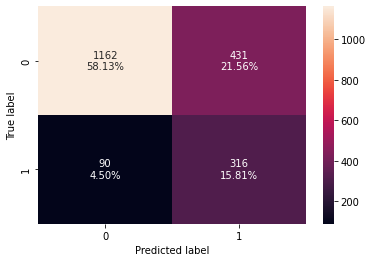

```python
 # predicting using the independent variables
threshold2=thresholds2

confusion_matrix_piped(y_test, y_pred_2)

# ------------------------------------------

acc2 = accuracy_score(y_test, y_pred_2)  # to compute Accuracy
recall2 = recall_score(y_test, y_pred_2,pos_label=1)  # to compute Recall
precision2 = precision_score(y_test, y_pred_2,pos_label=1)  # to compute Precision
f12 = f1_score(y_test, y_pred_2,pos_label=1)  # to compute F1-score

recall2_0 = recall_score(y_test, y_pred_2,pos_label=0)  # to compute Recall
precision2_0 = precision_score(y_test, y_pred_2,pos_label=0)  # to compute Precision
f12_0 = f1_score(y_test, y_pred_2,pos_label=0)  # to compute F1-score
print("Threshold = ",threshold2)

# creating a dataframe of metrics
df_perf2 = pd.DataFrame(
            {"Accuracy": acc2,"Recall_1": recall2, "Recall_0": recall2_0, "Precision_1": precision2, "Precision_0": precision2_0, "F1_1": f12, "F1_0": f12_0, "Threshold":threshold2},

    index=[0],
)
df_perf2
```

```
Threshold =  0.10730302
```

|  | Accuracy | Recall_1 | Recall_0 | Precision_1 | Precision_0 | F1_1 | F1_0 | Threshold |
| --- | --- | --- | --- | --- | --- | --- | --- | --- |
| 0 | 0.642821 | 0.876847 | 0.583176 | 0.34902 | 0.948927 | 0.499299 | 0.722395 | 0.107303 |

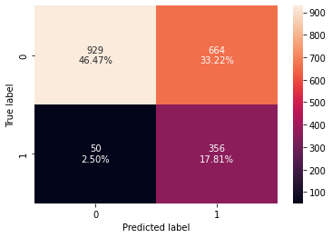

```python
 # predicting using the independent variables
threshold3=thresholds3

confusion_matrix_piped(y_test, y_pred_3)


acc3 = accuracy_score(y_test, y_pred_3)  # to compute Accuracy
recall3 = recall_score(y_test, y_pred_3,pos_label=1)  # to compute Recall
precision3 = precision_score(y_test, y_pred_3,pos_label=1)  # to compute Precision
f13 = f1_score(y_test, y_pred_3,pos_label=1)  # to compute F1-score

recall3_0 = recall_score(y_test, y_pred_3,pos_label=0)  # to compute Recall
precision3_0 = precision_score(y_test, y_pred_3,pos_label=0)  # to compute Precision
f13_0 = f1_score(y_test, y_pred_3,pos_label=0)  # to compute F1-score
print("Threshold = ",threshold3)

# creating a dataframe of metrics
df_perf3 = pd.DataFrame(
        {"Accuracy": acc3,"Recall_1": recall3, "Recall_0": recall3_0, "Precision_1": precision3, "Precision_0": precision3_0, "F1_1": f13, "F1_0": f13_0, "Threshold":threshold3},

    index=[0],
)
df_perf3
```

```
Threshold =  0.14864507
```

|  | Accuracy | Recall_1 | Recall_0 | Precision_1 | Precision_0 | F1_1 | F1_0 | Threshold |
| --- | --- | --- | --- | --- | --- | --- | --- | --- |
| 0 | 0.705353 | 0.805419 | 0.679849 | 0.390681 | 0.932014 | 0.526146 | 0.786207 | 0.148645 |

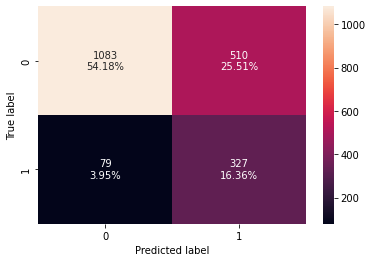

```python
 # predicting using the independent variables
threshold4=thresholds4

confusion_matrix_piped(y_test, y_pred_4)


acc4 = accuracy_score(y_test, y_pred_4)  # to compute Accuracy
recall4 = recall_score(y_test, y_pred_4,pos_label=1)  # to compute Recall
precision4 = precision_score(y_test, y_pred_4,pos_label=1)  # to compute Precision
f14 = f1_score(y_test, y_pred_4,pos_label=1)  # to compute F1-score

recall4_0 = recall_score(y_test, y_pred_4,pos_label=0)  # to compute Recall
precision4_0 = precision_score(y_test, y_pred_4,pos_label=0)  # to compute Precision
f14_0 = f1_score(y_test, y_pred_4,pos_label=0)  # to compute F1-score
print("Threshold = ",threshold4)

# creating a dataframe of metrics
df_perf4 = pd.DataFrame(
    {"Accuracy": acc4,"Recall_1": recall4, "Recall_0": recall4_0, "Precision_1": precision4, "Precision_0": precision4_0, "F1_1": f14, "F1_0": f14_0, "Threshold":threshold4},
    index=[0],
)
df_perf4
```

```
Threshold =  0.18199965
```

|  | Accuracy | Recall_1 | Recall_0 | Precision_1 | Precision_0 | F1_1 | F1_0 | Threshold |
| --- | --- | --- | --- | --- | --- | --- | --- | --- |
| 0 | 0.751876 | 0.76601 | 0.748274 | 0.436798 | 0.926185 | 0.556351 | 0.827778 | 0.182 |

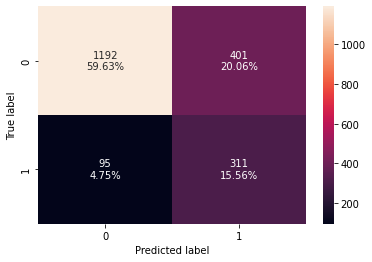

```python
 # predicting using the independent variables
threshold5=thresholds5

confusion_matrix_piped(y_test, y_pred_5)

acc5 = accuracy_score(y_test, y_pred_5)  # to compute Accuracy
recall5 = recall_score(y_test, y_pred_5,pos_label=1)  # to compute Recall
precision5 = precision_score(y_test, y_pred_5,pos_label=1)  # to compute Precision
f15 = f1_score(y_test, y_pred_5,pos_label=1)  # to compute F1-score

recall5_0 = recall_score(y_test, y_pred_5,pos_label=0)  # to compute Recall
precision5_0 = precision_score(y_test, y_pred_5,pos_label=0)  # to compute Precision
f15_0 = f1_score(y_test, y_pred_5,pos_label=0)  # to compute F1-score
print("Threshold = ",threshold5)

# creating a dataframe of metrics
df_perf5 = pd.DataFrame(
     {"Accuracy": acc5,"Recall_1": recall5, "Recall_0": recall5_0, "Precision_1": precision5, "Precision_0": precision5_0, "F1_1": f15, "F1_0": f15_0, "Threshold":threshold5},
    index=[0],
)
df_perf5
```

```
Threshold =  0.20624697
```

|  | Accuracy | Recall_1 | Recall_0 | Precision_1 | Precision_0 | F1_1 | F1_0 | Threshold |
| --- | --- | --- | --- | --- | --- | --- | --- | --- |
| 0 | 0.777389 | 0.736453 | 0.787822 | 0.469388 | 0.921439 | 0.573346 | 0.849408 | 0.206247 |

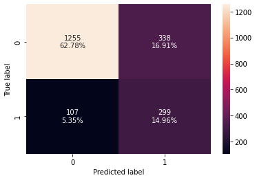

```python
 # predicting using the independent variables
threshold6=thresholds6

confusion_matrix_piped(y_test, y_pred_6)


acc6 = accuracy_score(y_test, y_pred_6)  # to compute Accuracy
recall6 = recall_score(y_test, y_pred_6,pos_label=1)  # to compute Recall
precision6 = precision_score(y_test, y_pred_6,pos_label=1)  # to compute Precision
f16 = f1_score(y_test, y_pred_6,pos_label=1)  # to compute F1-score

recall6_0 = recall_score(y_test, y_pred_6,pos_label=0)  # to compute Recall
precision6_0 = precision_score(y_test, y_pred_6,pos_label=0)  # to compute Precision
f16_0 = f1_score(y_test, y_pred_6,pos_label=0)  # to compute F1-score
print("Threshold = ",threshold6)

# creating a dataframe of metrics
df_perf6 = pd.DataFrame(    {"Accuracy": acc6,"Recall_1": recall6, "Recall_0": recall6_0, "Precision_1": precision6, "Precision_0": precision6_0, "F1_1": f16, "F1_0": f16_0, "Threshold":threshold6},

    index=[0],

)
df_perf6
```

```python
backend.clear_session()
np.random.seed(42)
import random
random.seed(42)
tf.random.set_seed(42)
```

```python
# training performance comparison

models_test_comp_df = pd.concat([df_perf1.T,df_perf2.T,df_perf3.T,df_perf4.T,df_perf5.T,df_perf6.T,],axis=1,)
#models_test_comp_df = pd.concat([df_perf2.T,df_perf3.T,df_perf4.T,df_perf5.T,df_perf6.T,],axis=1,)

models_test_comp_df.columns = [
     "Basic Model SGD Optimizer",

    "Basic Model Adam Optimizer",
    "Batch Normalization Model",
    "Dropout Model",
    "Early Stopped Model",
    "Hyperparameter Tuned Model",
]
print("Testing performance comparison:")
models_test_comp_df
```

```
Testing performance comparison:
```

|  | Basic Model SGD Optimizer | Basic Model Adam Optimizer | Batch Normalization Model | Dropout Model | Early Stopped Model | Hyperparameter Tuned Model |
| --- | --- | --- | --- | --- | --- | --- |
| Accuracy | 0.781391 | 0.739370 | 0.642821 | 0.705353 | 0.751876 | 0.777389 |
| Recall_1 | 0.729064 | 0.778325 | 0.876847 | 0.805419 | 0.766010 | 0.736453 |
| Recall_0 | 0.794727 | 0.729441 | 0.583176 | 0.679849 | 0.748274 | 0.787822 |
| Precision_1 | 0.475120 | 0.423025 | 0.349020 | 0.390681 | 0.436798 | 0.469388 |
| Precision_0 | 0.920058 | 0.928115 | 0.948927 | 0.932014 | 0.926185 | 0.921439 |
| F1_1 | 0.575316 | 0.548135 | 0.499299 | 0.526146 | 0.556351 | 0.573346 |
| F1_0 | 0.852812 | 0.816872 | 0.722395 | 0.786207 | 0.827778 | 0.849408 |
| Threshold | 0.210501 | 0.115267 | 0.107303 | 0.148645 | 0.182000 | 0.206247 |

**Visualising model predictions on a dataframe for the Basic Model with SGD Optimizer**

```python
backend.clear_session()
np.random.seed(42)
import random
random.seed(42)
tf.random.set_seed(42)
```

```python
y_test_1_da = pd.DataFrame(y_test_test)  # Convert to dataframe
pred1=(y_pred_1 > threshold1)
test_pred_da = pd.DataFrame(pred1)
#test_pred_da=test_pred_da.replace({"True":"1", "False":"0"})

X_test_1_da = pd.DataFrame(X_test_test)
```

```python
y_test_1_da.reset_index(drop=True, inplace=True)  # reset index
y_test_1_da.reset_index(drop=True, inplace=True)
test_pred_da.reset_index(drop=True, inplace=True)
```

```python
test_pred_da.columns = [
    "Predicted_Exit"
]  # Assign a column name to Predicted Test Data
```

```python
test_pred_da=test_pred_da.astype(int).replace({'True':'1', 'False':'0'})
```

```python
test_da_frame=pd.concat(
    [X_test_1_da, y_test_1_da, test_pred_da], axis=1
)  # Concatenate original
test_da_frame
```

|  | CreditScore | Geography | Gender | Age | Tenure | Balance | NumOfProducts | HasCrCard | IsActiveMember | EstimatedSalary | Exited | Predicted_Exit |
| --- | --- | --- | --- | --- | --- | --- | --- | --- | --- | --- | --- | --- |
| 0 | NaN | NaN | NaN | NaN | NaN | NaN | NaN | NaN | NaN | NaN | 0.0 | 1.0 |
| 1 | NaN | NaN | NaN | NaN | NaN | NaN | NaN | NaN | NaN | NaN | 0.0 | 1.0 |
| 2 | NaN | NaN | NaN | NaN | NaN | NaN | NaN | NaN | NaN | NaN | 0.0 | 0.0 |
| 3 | NaN | NaN | NaN | NaN | NaN | NaN | NaN | NaN | NaN | NaN | 0.0 | 0.0 |
| 4 | NaN | NaN | NaN | NaN | NaN | NaN | NaN | NaN | NaN | NaN | 0.0 | 0.0 |
| ... | ... | ... | ... | ... | ... | ... | ... | ... | ... | ... | ... | ... |
| 9977 | 683.0 | France | Female | 32.0 | 9 | 0.00 | 2 | 1 | 1 | 24991.92 | NaN | NaN |
| 9979 | 677.0 | France | Female | 58.0 | 1 | 90022.85 | 1 | 0 | 1 | 2988.28 | NaN | NaN |
| 9982 | 655.0 | Germany | Female | 46.0 | 7 | 137145.12 | 1 | 1 | 0 | 115146.40 | NaN | NaN |
| 9985 | 659.0 | France | Male | 36.0 | 6 | 123841.49 | 2 | 1 | 0 | 96833.00 | NaN | NaN |
| 9998 | 772.0 | Germany | Male | 42.0 | 3 | 75075.31 | 2 | 1 | 0 | 92888.52 | NaN | NaN |

3627 rows × 12 columns

```python
def confusion_matrix_piped(real_target, pred_target):
    """
    To plot the confusion_matrix with percentages

    model: classifier
    predictors: independent variables
    target: dependent variable
    """
    cm = confusion_matrix(real_target, pred_target)
    labels = np.asarray(
        [
            ["{0:0.0f}".format(item) + "\n{0:.2%}".format(item / cm.flatten().sum())]
            for item in cm.flatten()
        ]
    ).reshape(2, 2)

    plt.figure(figsize=(6, 4))
    sns.heatmap(cm, annot=labels, fmt="")
    plt.ylabel("True label")
    plt.xlabel("Predicted label")
```

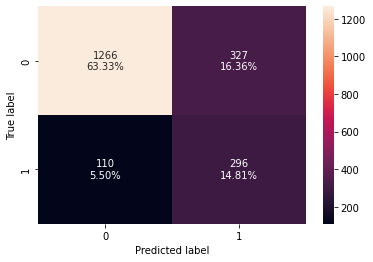

```python
confusion_matrix_piped(y_test_1_da, test_pred_da)
```

**Improving the models by undersampling and oversampling techniques**

**Undersampling Approach**

```python
backend.clear_session()
np.random.seed(42)
import random
random.seed(42)
tf.random.set_seed(42)
```

```python
# fit random under sampler on the train data
rus = RandomUnderSampler(random_state=1, sampling_strategy=1)
X_train_un, y_train_un = rus.fit_resample(X_train, y_train)
```

```python
X_train_un
```

|  | CreditScore | Age | Balance | EstimatedSalary | Geography_1 | Geography_2 | Gender_1 | Tenure_1 | Tenure_2 | Tenure_3 | Tenure_4 | Tenure_5 | Tenure_6 | Tenure_7 | Tenure_8 | Tenure_9 | Tenure_10 | NumOfProducts_2 | NumOfProducts_3 | NumOfProducts_4 | HasCrCard_1 | IsActiveMember_1 |
| --- | --- | --- | --- | --- | --- | --- | --- | --- | --- | --- | --- | --- | --- | --- | --- | --- | --- | --- | --- | --- | --- | --- |
| 0 | 0.443532 | 0.554054 | 0.620926 | 0.374123 | 0 | 1 | 0 | 0 | 0 | 1 | 0 | 0 | 0 | 0 | 0 | 0 | 0 | 0 | 0 | 0 | 1 | 1 |
| 1 | 0.396304 | 0.581081 | 0.492557 | 0.470548 | 0 | 0 | 0 | 0 | 1 | 0 | 0 | 0 | 0 | 0 | 0 | 0 | 0 | 0 | 0 | 0 | 1 | 1 |
| 2 | 0.466119 | 0.783784 | 0.675286 | 0.068826 | 0 | 0 | 0 | 0 | 0 | 0 | 0 | 1 | 0 | 0 | 0 | 0 | 0 | 0 | 0 | 0 | 0 | 1 |
| 3 | 0.494867 | 0.297297 | 0.000000 | 0.615886 | 0 | 0 | 0 | 1 | 0 | 0 | 0 | 0 | 0 | 0 | 0 | 0 | 0 | 1 | 0 | 0 | 1 | 0 |
| 4 | 0.714579 | 0.310811 | 0.000000 | 0.968760 | 0 | 0 | 1 | 0 | 0 | 1 | 0 | 0 | 0 | 0 | 0 | 0 | 0 | 1 | 0 | 0 | 1 | 1 |
| ... | ... | ... | ... | ... | ... | ... | ... | ... | ... | ... | ... | ... | ... | ... | ... | ... | ... | ... | ... | ... | ... | ... |
| 3241 | 0.827515 | 0.121622 | 0.529750 | 0.888054 | 1 | 0 | 1 | 0 | 0 | 0 | 0 | 1 | 0 | 0 | 0 | 0 | 0 | 0 | 0 | 0 | 1 | 0 |
| 3242 | 0.392197 | 0.337838 | 0.000000 | 0.748060 | 0 | 0 | 0 | 0 | 0 | 0 | 0 | 0 | 0 | 0 | 0 | 0 | 1 | 1 | 0 | 0 | 1 | 0 |
| 3243 | 0.774127 | 0.337838 | 0.000000 | 0.996489 | 0 | 1 | 1 | 0 | 0 | 0 | 0 | 0 | 0 | 0 | 0 | 1 | 0 | 0 | 0 | 0 | 1 | 0 |
| 3244 | 0.702259 | 0.297297 | 0.854554 | 0.899882 | 0 | 1 | 0 | 0 | 0 | 0 | 0 | 1 | 0 | 0 | 0 | 0 | 0 | 0 | 0 | 0 | 1 | 0 |
| 3245 | 0.772074 | 0.540541 | 0.463941 | 0.800554 | 1 | 0 | 1 | 1 | 0 | 0 | 0 | 0 | 0 | 0 | 0 | 0 | 0 | 0 | 0 | 0 | 0 | 1 |

3246 rows × 22 columns

```python
y_train_un
```

|  | Exited |
| --- | --- |
| 0 | 0 |
| 1 | 0 |
| 2 | 0 |
| 3 | 0 |
| 4 | 0 |
| ... | ... |
| 3241 | 1 |
| 3242 | 1 |
| 3243 | 1 |
| 3244 | 1 |
| 3245 | 1 |

3246 rows × 1 columns

```python
y_train.value_counts()
```

```
Exited
0         6370
1         1623
dtype: int64
```

```python
y_train_un.value_counts()
```

```
Exited
0         1623
1         1623
dtype: int64
```

**Let's train the model using the undersampled data**

```python
# Initializing the ANN
model42 = Sequential()
#Add input and 1st hidden layer
model42.add(Dense(units=64, activation='relu',kernel_initializer='he_uniform', input_dim = X_train_un.shape[1]))
model42.add(Dropout(0.2))
#Add 2nd hidden layer
model42.add(Dense(64, activation='relu',kernel_initializer='he_uniform',))
#model42.add(Dropout(0.4))

#Add 3rd hidden layer
#model42.add(Dense(64, activation='relu',kernel_initializer='he_uniform',))
#model42.add(Dropout(0.2))

# Adding the output layer
# Notice that we do not need to specify input dim.
# we have an output of 1 node, which is the the desired dimensions of our output (stay with the bank or not)
# We use the sigmoid because we want probability outcomes
model42.add(Dense(1, activation = 'sigmoid'))
```

```python
model42.summary()
```

```
Model: "sequential"
_________________________________________________________________
 Layer (type)                Output Shape              Param #
=================================================================
 dense (Dense)               (None, 64)                1472

 dropout (Dropout)           (None, 64)                0

 dense_1 (Dense)             (None, 64)                4160

 dense_2 (Dense)             (None, 1)                 65

=================================================================
Total params: 5,697
Trainable params: 5,697
Non-trainable params: 0
_________________________________________________________________
```

```python
# Create optimizer with default learning rate
# Compile the model
Adam = optimizers.Adam(lr=1e-3)
model42.compile(loss=losses.binary_crossentropy, optimizer=Adam, metrics=['accuracy'])
```

```python
history42=model42.fit(X_train_un, y_train_un,
          validation_split=0.2,
          epochs=100,
          batch_size=32,verbose=1)
```

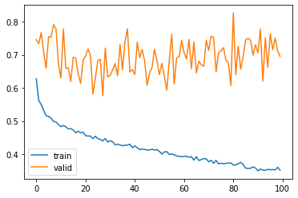

```python
# Capturing learning history per epoch
hist42  = pd.DataFrame(history42.history)
hist42['epoch'] = history42.epoch

# Plotting accuracy at different epochs
plt.plot(hist42['loss'])
plt.plot(hist42['val_loss'])
plt.legend(("train" , "valid") , loc =0)

#Printing results
results_42 = model42.evaluate(X_test, y_test)
```

```
Best Threshold=0.401616, G-Mean=0.756
```

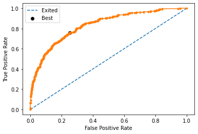

```python
from sklearn.metrics import roc_curve

from matplotlib import pyplot


# predict probabilities
yhat42 = model42.predict(X_test)
# keep probabilities for the positive outcome only
yhat42 = yhat42[:, 0]
# calculate roc curves
fpr, tpr, thresholds1 = roc_curve(y_test, yhat42)
# calculate the g-mean for each threshold
gmeans42 = np.sqrt(tpr * (1-fpr))
# locate the index of the largest g-mean
ix42 = np.argmax(gmeans42)
print('Best Threshold=%f, G-Mean=%.3f' % (thresholds1[ix42], gmeans5[ix42]))
# plot the roc curve for the model
pyplot.plot([0,1], [0,1], linestyle='--', label='Exited')
pyplot.plot(fpr, tpr, marker='.')
pyplot.scatter(fpr[ix42], tpr[ix42], marker='o', color='black', label='Best')
# axis labels
pyplot.xlabel('False Positive Rate')
pyplot.ylabel('True Positive Rate')
pyplot.legend()
# show the plot
pyplot.show()
```

```python
#Predicting the results using best as a threshold
y_pred_42=model42.predict(X_test)
y_pred_42 = (y_pred_42 > thresholds1[ix42])
y_pred_42
```

```
array([[False],
       [ True],
       [ True],
       ...,
       [False],
       [ True],
       [False]])
```

```python
thresholds42=thresholds1[ix42]
```

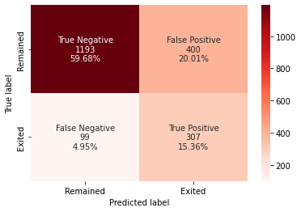

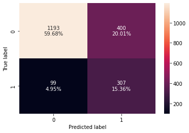

```python
#Calculating the confusion matrix
from sklearn.metrics import confusion_matrix
cm42=confusion_matrix(y_test, y_pred_42)
labels = ['True Negative','False Positive','False Negative','True Positive']
categories = [ 'Remained','Exited']
make_confusion_matrix(cm42,
                      group_names=labels,
                      categories=categories,
                      cmap='Reds')
plt.ylabel("True label")
plt.xlabel("Predicted label")

confusion_matrix_piped(y_test, y_pred_42)
```

```python
#Accuracy as per the classification report
from sklearn import metrics
cr42=metrics.classification_report(y_test,y_pred_42)
print(cr42)
```

```
              precision    recall  f1-score   support

           0       0.92      0.75      0.83      1593
           1       0.43      0.76      0.55       406

    accuracy                           0.75      1999
   macro avg       0.68      0.75      0.69      1999
weighted avg       0.82      0.75      0.77      1999
```

```python
 # predicting using the independent variables

acc42 = accuracy_score(y_test, y_pred_42)  # to compute Accuracy
recall42 = recall_score(y_test, y_pred_42,pos_label=1)  # to compute Recall
precision42 = precision_score(y_test, y_pred_42, pos_label=1)  # to compute Precision
f142 = f1_score(y_test, y_pred_42,pos_label=1)  # to compute F1-score

recall42_0 = recall_score(y_test, y_pred_42,pos_label=0)  # to compute Recall
precision42_0 = precision_score(y_test, y_pred_42, pos_label=0)  # to compute Precision
f142_0 = f1_score(y_test, y_pred_42,pos_label=0)  # to compute F1-score
print("Threshold = ",thresholds42)

# creating a dataframe of metrics
df_perf42 = pd.DataFrame(
    {"Accuracy": acc42,"Recall_1": recall42, "Recall_0": recall42_0, "Precision_1": precision42, "Precision_0": precision42_0, "F1_1": f142, "F1_0": f142_0, "Threshold":thresholds42},
    index=[0],
)
df_perf42
```

```
Threshold =  0.4016159
```

|  | Accuracy | Recall_1 | Recall_0 | Precision_1 | Precision_0 | F1_1 | F1_0 | Threshold |
| --- | --- | --- | --- | --- | --- | --- | --- | --- |
| 0 | 0.750375 | 0.756158 | 0.748901 | 0.434229 | 0.923375 | 0.551662 | 0.827036 | 0.401616 |

**Oversampling**

```python
backend.clear_session()
np.random.seed(42)
import random
random.seed(42)
tf.random.set_seed(42)
```

```python
# Fit SMOTE on train data(Synthetic Minority Oversampling Technique)
sm = SMOTE(sampling_strategy=1, k_neighbors=5, random_state=1)
X_train_over, y_train_over = sm.fit_resample(X_train, y_train)
```

```python
y_train_over.value_counts()
```

```
Exited
0         6370
1         6370
dtype: int64
```

```python
# Initializing the ANN
model43 = Sequential()
#Add input and 1st hidden layer
model43.add(Dense(units=64, activation='relu',kernel_initializer='he_uniform', input_dim = X_train_over.shape[1]))
model43.add(Dropout(0.2))
#Add 2nd hidden layer
model43.add(Dense(64, activation='relu',kernel_initializer='he_uniform',))
#model43.add(Dropout(0.4))

#Add 3rd hidden layer
#model43.add(Dense(64, activation='relu',kernel_initializer='he_uniform',))
#model43.add(Dropout(0.2))

# Adding the output layer
# Notice that we do not need to specify input dim.
# we have an output of 1 node, which is the the desired dimensions of our output (stay with the bank or not)
# We use the sigmoid because we want probability outcomes
model43.add(Dense(1, activation = 'sigmoid'))
```

```python
model43.summary()
```

```
Model: "sequential"
_________________________________________________________________
 Layer (type)                Output Shape              Param #
=================================================================
 dense (Dense)               (None, 64)                1472

 dropout (Dropout)           (None, 64)                0

 dense_1 (Dense)             (None, 64)                4160

 dense_2 (Dense)             (None, 1)                 65

=================================================================
Total params: 5,697
Trainable params: 5,697
Non-trainable params: 0
_________________________________________________________________
```

```python
# Create optimizer with default learning rate
# Compile the model
Adam = optimizers.Adam(lr=1e-3)
model43.compile(loss=losses.binary_crossentropy, optimizer=Adam, metrics=['accuracy'])
```

```python
history43=model43.fit(X_train_over, y_train_over,
          validation_split=0.2,
          epochs=100,
          batch_size=32,verbose=1)
```

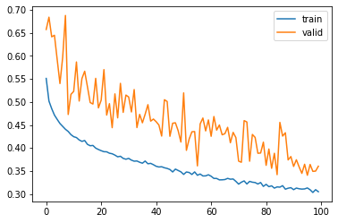

```python
# Capturing learning history per epoch
hist43  = pd.DataFrame(history43.history)
hist43['epoch'] = history43.epoch

# Plotting accuracy at different epochs
plt.plot(hist43['loss'])
plt.plot(hist43['val_loss'])
plt.legend(("train" , "valid") , loc =0)

#Printing results
results_43 = model43.evaluate(X_test, y_test)
```

```
Best Threshold=0.246273, G-Mean=0.762
```

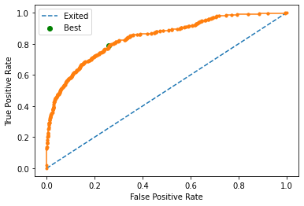

```python
from sklearn.metrics import roc_curve

from matplotlib import pyplot


# predict probabilities
yhat43 = model43.predict(X_test)
# keep probabilities for the positive outcome only
yhat43 = yhat43[:, 0]
# calculate roc curves
fpr, tpr, thresholds1 = roc_curve(y_test, yhat43)
# calculate the g-mean for each threshold
gmeans43 = np.sqrt(tpr * (1-fpr))
# locate the index of the largest g-mean
ix43 = np.argmax(gmeans43)
print('Best Threshold=%f, G-Mean=%.3f' % (thresholds1[ix43], gmeans5[ix43]))
# plot the roc curve for the model
pyplot.plot([0,1], [0,1], linestyle='--', label='Exited')
pyplot.plot(fpr, tpr, marker='.')
pyplot.scatter(fpr[ix43], tpr[ix43], marker='o', color='green', label='Best')
# axis labels
pyplot.xlabel('False Positive Rate')
pyplot.ylabel('True Positive Rate')
pyplot.legend()
# show the plot
pyplot.show()
```

```python
#Predicting the results using best as a threshold
y_pred_43=model43.predict(X_test)
y_pred_43 = (y_pred_43 > thresholds1[ix43])
y_pred_43
```

```
array([[False],
       [ True],
       [ True],
       ...,
       [False],
       [ True],
       [False]])
```

```python
thresholds43=thresholds1[ix43]
```

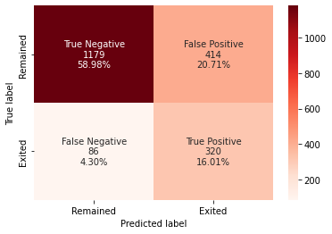

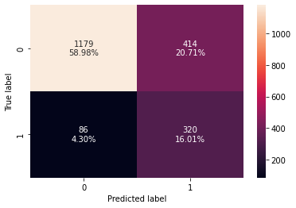

```python
#Calculating the confusion matrix
from sklearn.metrics import confusion_matrix
cm43=confusion_matrix(y_test, y_pred_43)
labels = ['True Negative','False Positive','False Negative','True Positive']
categories = [ 'Remained','Exited']
make_confusion_matrix(cm43,
                      group_names=labels,
                      categories=categories,
                      cmap='Reds')
plt.ylabel("True label")
plt.xlabel("Predicted label")

confusion_matrix_piped(y_test, y_pred_43)
```

```python
#Accuracy as per the classification report
from sklearn import metrics
cr43=metrics.classification_report(y_test,y_pred_43)
print(cr43)
```

```
              precision    recall  f1-score   support

           0       0.93      0.74      0.83      1593
           1       0.44      0.79      0.56       406

    accuracy                           0.75      1999
   macro avg       0.68      0.76      0.69      1999
weighted avg       0.83      0.75      0.77      1999
```

```python
 # predicting using the independent variables
threshold3=thresholds3
acc43 = accuracy_score(y_test, y_pred_43)  # to compute Accuracy
recall43 = recall_score(y_test, y_pred_43,pos_label=1)  # to compute Recall
precision43 = precision_score(y_test, y_pred_43, pos_label=1)  # to compute Precision
f143 = f1_score(y_test, y_pred_43,pos_label=1)  # to compute F1-score

recall43_0 = recall_score(y_test, y_pred_43,pos_label=0)  # to compute Recall
precision43_0 = precision_score(y_test, y_pred_43, pos_label=0)  # to compute Precision
f143_0 = f1_score(y_test, y_pred_43,pos_label=0)  # to compute F1-score
print("Threshold = ",thresholds43)

# creating a dataframe of metrics
df_perf43 = pd.DataFrame(
    {"Accuracy": acc43,"Recall_1": recall43, "Recall_0": recall43_0, "Precision_1": precision43, "Precision_0": precision43_0, "F1_1": f143, "F1_0": f143_0, "Threshold":thresholds43},
    index=[0],
)
df_perf43
```

```
Threshold =  0.24627274
```

|  | Accuracy | Recall_1 | Recall_0 | Precision_1 | Precision_0 | F1_1 | F1_0 | Threshold |
| --- | --- | --- | --- | --- | --- | --- | --- | --- |
| 0 | 0.749875 | 0.788177 | 0.740113 | 0.435967 | 0.932016 | 0.561404 | 0.825052 | 0.246273 |

```python
# training performance comparison

models_test_comp_df = pd.concat([df_perf1.T,df_perf2.T,df_perf3.T,df_perf4.T,df_perf5.T,df_perf6.T,df_perf42.T,df_perf43.T],axis=1,)
#models_test_comp_df = pd.concat([df_perf2.T,df_perf3.T,df_perf4.T,df_perf5.T,df_perf6.T,],axis=1,)

models_test_comp_df.columns = [
     "Basic Model SGD Optimizer",

    "Basic Model Adam Optimizer",
    "Batch Normalization Model",
    "Dropout Model",
    "Early Stopped Model",
    "Hyperparameter Tuned Model",
    "Dropout Undersampled Model",
    "Dropout Oversampled Model",

]
print("Testing performance comparison:")
models_test_comp_df
```

```
Testing performance comparison:
```

|  | Basic Model SGD Optimizer | Basic Model Adam Optimizer | Batch Normalization Model | Dropout Model | Early Stopped Model | Hyperparameter Tuned Model | Dropout Undersampled Model | Dropout Oversampled Model |
| --- | --- | --- | --- | --- | --- | --- | --- | --- |
| Accuracy | 0.781391 | 0.739370 | 0.642821 | 0.705353 | 0.751876 | 0.777389 | 0.750375 | 0.749875 |
| Recall_1 | 0.729064 | 0.778325 | 0.876847 | 0.805419 | 0.766010 | 0.736453 | 0.756158 | 0.788177 |
| Recall_0 | 0.794727 | 0.729441 | 0.583176 | 0.679849 | 0.748274 | 0.787822 | 0.748901 | 0.740113 |
| Precision_1 | 0.475120 | 0.423025 | 0.349020 | 0.390681 | 0.436798 | 0.469388 | 0.434229 | 0.435967 |
| Precision_0 | 0.920058 | 0.928115 | 0.948927 | 0.932014 | 0.926185 | 0.921439 | 0.923375 | 0.932016 |
| F1_1 | 0.575316 | 0.548135 | 0.499299 | 0.526146 | 0.556351 | 0.573346 | 0.551662 | 0.561404 |
| F1_0 | 0.852812 | 0.816872 | 0.722395 | 0.786207 | 0.827778 | 0.849408 | 0.827036 | 0.825052 |
| Threshold | 0.210501 | 0.115267 | 0.107303 | 0.148645 | 0.182000 | 0.206247 | 0.401616 | 0.246273 |

**Conclusion and Key Takeaways**

- The best model is the basic model with SGD Optimizer as it has the highest F1 score.
- At least 50% of the customers have a credit score up to 652.
- At least 50% of the customers are 37 years of age.
- At least 50% of the customers have spent 5 years tenure with the bank.
- At least 50% of the customers have a balance of £97198 in their account and at least less than 25% of the customers have no balance in their account.
- All the customers have used at least a product. At least 25% of the customers have used two products of the bank.
- At least 50% of the customers have a credit card and are active members.
- At least 75% of the customers have estimated salary above £51000 and over 50% of the customers have estimated salary over £100193.
- Over 75% of the customers remained with the bank.
- There is no strong correlation between any of the variables.
- Relatively, there is a positive correlation between Age and Exited (0.29); a negative correlation between Balance and NumOfProducts (-0.30); and a negative correlation between IsActiveMember and Exited (-0.16).
- Even though these correlations are not strong, one can infer that as age of a customer increases they tend to exit the bank as they begin to feel dissatisfied as their status gets higher and personal concern for their financial security after they retire.
- Also, Customers with higher balance use fewer number of products as they are not investing much into more products, they have more active balances in their accounts.
- Finally, customers that are active members may not want to exit as they appear to be loyal customers.
- More Germans exited.
- More Females exited compared to male.
- Most people on two products remained with the bank.
- More non-active members exited the bank.
- Customers with higher balance exited except those on a single product.
- For all the products, customers with higher estimated salary exited.
- Customers with lower credit scores exited
- It is possible those on a single product have higher credit scores.

**Recommendations**

- Based on the analysis as age of a customer increases they tend to exit the bank as they begin to feel dissatisfied as their status gets higher and personal concern for their financial security after they retire. So, the bank should create a segment of customers and create a good customer service system to attend to this category of customers and reassure them of their financial security.
- Also, Customers with higher balance use fewer number of products as they are not investing much into more products, they have more active balances in their accounts. So, the bank should encourage some customized products for these customers to use their balances to invest in the bank in the different products created.
- Finally, customers that are active members may not want to exit as they appear to be loyal customers. These set of customers should receive continued support in the bank and incentives to keep them with the bank.
- More Germans exited. Possibly some of the German customers might require services offered in German language. So the bank should look into employer some excellent German speakers in the bank in case any of the customers require such service.